# All Life Customer Segmentaion

### Background:

This work shows segmentation analysis of All Life Bank credit card customers in order to:

1. Improve current existing marketing
2. Help in new customers targeting
3. Improve customer service

### Objective:

To identify different segments in the existing customer based on their spending patterns as well as past interaction with the bank.

#### Key Questions to answer:

1. How many different segments of customers are there
2. How are these segments different from each other
3. Possible recommendations to the bank on how to better market to and service these customers

#### Data Description:

- Data is of various customers of a bank with their credit limit, the total number of credit cards the customer has, and different channels through which customer has contacted the bank for any queries, different channels include visiting the bank, online and through a call centre.

```python
#Import all the necessary modules
import pandas as pd
import numpy as np
import os
import seaborn as sns
import matplotlib.pyplot as plt
%matplotlib inline

from scipy.stats import zscore
from sklearn.model_selection import train_test_split

from sklearn.cluster import KMeans
```

```python
#Load data from Excel

df = pd.read_excel(
     os.path.join("Credit Card Customer Data.xlsx"),
     engine='openpyxl',
)

df.head()
```

|  | Sl_No | Customer Key | Avg_Credit_Limit | Total_Credit_Cards | Total_visits_bank | Total_visits_online | Total_calls_made |
| --- | --- | --- | --- | --- | --- | --- | --- |
| 0 | 1 | 87073 | 100000 | 2 | 1 | 1 | 0 |
| 1 | 2 | 38414 | 50000 | 3 | 0 | 10 | 9 |
| 2 | 3 | 17341 | 50000 | 7 | 1 | 3 | 4 |
| 3 | 4 | 40496 | 30000 | 5 | 1 | 1 | 4 |
| 4 | 5 | 47437 | 100000 | 6 | 0 | 12 | 3 |

```python
df.shape
```

```
(660, 7)
```

```python
df.info()
```

```
<class 'pandas.core.frame.DataFrame'>
RangeIndex: 660 entries, 0 to 659
Data columns (total 7 columns):
 #   Column               Non-Null Count  Dtype
---  ------               --------------  -----
 0   Sl_No                660 non-null    int64
 1   Customer Key         660 non-null    int64
 2   Avg_Credit_Limit     660 non-null    int64
 3   Total_Credit_Cards   660 non-null    int64
 4   Total_visits_bank    660 non-null    int64
 5   Total_visits_online  660 non-null    int64
 6   Total_calls_made     660 non-null    int64
dtypes: int64(7)
memory usage: 36.2 KB
```

`All data is numerical`

### Univariate EDA

- Perform univariate analysis on the data to better understand the variables at your disposal and to get an idea about the no of clusters. Perform EDA, create visualizations to explore data. (10 marks)

```python
df.isna().sum()
```

```
Sl_No                  0
Customer Key           0
Avg_Credit_Limit       0
Total_Credit_Cards     0
Total_visits_bank      0
Total_visits_online    0
Total_calls_made       0
dtype: int64
```

```python
df.describe().T
```

|  | count | mean | std | min | 25% | 50% | 75% | max |
| --- | --- | --- | --- | --- | --- | --- | --- | --- |
| Sl_No | 660.0 | 330.500000 | 190.669872 | 1.0 | 165.75 | 330.5 | 495.25 | 660.0 |
| Customer Key | 660.0 | 55141.443939 | 25627.772200 | 11265.0 | 33825.25 | 53874.5 | 77202.50 | 99843.0 |
| Avg_Credit_Limit | 660.0 | 34574.242424 | 37625.487804 | 3000.0 | 10000.00 | 18000.0 | 48000.00 | 200000.0 |
| Total_Credit_Cards | 660.0 | 4.706061 | 2.167835 | 1.0 | 3.00 | 5.0 | 6.00 | 10.0 |
| Total_visits_bank | 660.0 | 2.403030 | 1.631813 | 0.0 | 1.00 | 2.0 | 4.00 | 5.0 |
| Total_visits_online | 660.0 | 2.606061 | 2.935724 | 0.0 | 1.00 | 2.0 | 4.00 | 15.0 |
| Total_calls_made | 660.0 | 3.583333 | 2.865317 | 0.0 | 1.00 | 3.0 | 5.00 | 10.0 |

```python
df.nunique()
```

```
Sl_No                  660
Customer Key           655
Avg_Credit_Limit       110
Total_Credit_Cards      10
Total_visits_bank        6
Total_visits_online     16
Total_calls_made        11
dtype: int64
```

`Checking duplicates`

```python
dups = df.duplicated()
print('Number of duplicate rows = %d' % (dups.sum()))

df[dups]
```

```
Number of duplicate rows = 0
```

|  | Sl_No | Customer Key | Avg_Credit_Limit | Total_Credit_Cards | Total_visits_bank | Total_visits_online | Total_calls_made |
| --- | --- | --- | --- | --- | --- | --- | --- |

```python
df['Customer Key'].duplicated().sum()
```

```
5
```

### Insights:

- All numerical values, no NANs or missing.
- 660 unique SI_No, 5 Customer Keys are duplicated; although they are not dropped due to the unique SI_No, no other duplicated values (can be typo mitake?), and because this variable is dropped for the analysis later.
- Average Credit Limit variable is skewed to the right.

```python
# SI_No and Customer Key columns is to identify rows and customers ID, hence can be skipped in analysis

df1=df.drop(['Sl_No', 'Customer Key'], axis=1)
```

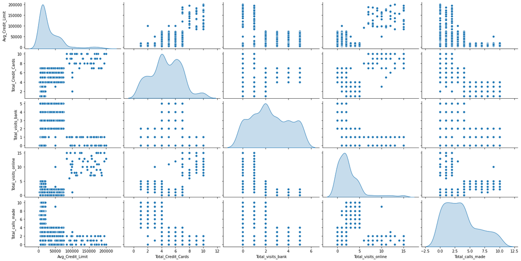

```python
#importing seaborn for statistical plots
sns.pairplot(df1, height=2, aspect=2, diag_kind='kde')
```

```python
# Check for correlation of variable
df1.corr(method='pearson')
```

|  | Avg_Credit_Limit | Total_Credit_Cards | Total_visits_bank | Total_visits_online | Total_calls_made |
| --- | --- | --- | --- | --- | --- |
| Avg_Credit_Limit | 1.000000 | 0.608860 | -0.100312 | 0.551385 | -0.414352 |
| Total_Credit_Cards | 0.608860 | 1.000000 | 0.315796 | 0.167758 | -0.651251 |
| Total_visits_bank | -0.100312 | 0.315796 | 1.000000 | -0.551861 | -0.506016 |
| Total_visits_online | 0.551385 | 0.167758 | -0.551861 | 1.000000 | 0.127299 |
| Total_calls_made | -0.414352 | -0.651251 | -0.506016 | 0.127299 | 1.000000 |

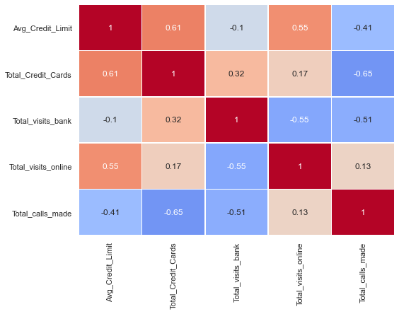

```python
# Correlations heat map

sns.set(rc={'figure.figsize':(8, 6)})
sns.heatmap(df1.corr(),
            annot=True,
            linewidths=0.5,
            center=0,
            cbar=False,
            cmap="coolwarm")
plt.show()
```

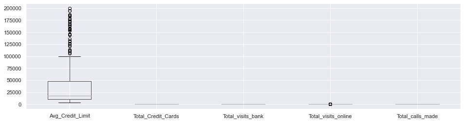

```python
df1.boxplot(figsize=(16,4))
```

### Insights:

- Histograms suggest 4 to 6 different clusters.
- Scaling is must due to very large values of Avr Credit Limit vs. others.
- Strongest positive correlations are between:
  - Avr Credit Limit and Total Credit Cards (as it should, each credit cards adds more credit);
  - Avr Credit Limit and Total Visits Online
- Strongest negative correlations are between:
  - Avr Credit Limit and Total Calls made
  - Total Credit Cards and Total Calls made: can suggest cluster of phone communicators with smaller number of credit cards
  - Total Visits Online Cards and Total Visits bank: can suggest different clusters of 'onliners' vs. 'onsiters'
- Avr Credit Limit is skewed with multiple outliers - need log transform
- Total Visits Online also has outliers, and need to be re-structured

```python
df1['Total_visits_online'].value_counts()
```

```
2     189
0     144
1     109
4      69
5      54
3      44
15     10
7       7
12      6
10      6
8       6
13      5
11      5
9       4
14      1
6       1
Name: Total_visits_online, dtype: int64
```

```python
# Restructuring the Total Visits Online variable: can be asigned to one category if above 6

df2=df1.copy()

df2['Total_visits_online'] = np.where(df2['Total_visits_online'] > 6, 6, df2['Total_visits_online'])
df2['Total_visits_online'].value_counts()
```

```
2    189
0    144
1    109
4     69
5     54
6     51
3     44
Name: Total_visits_online, dtype: int64
```

```python
# Log transform for Avg Credit Limit variable

df2['Avg_Credit_Limit_log']=np.log1p(df2['Avg_Credit_Limit'])

df2.drop(['Avg_Credit_Limit'], axis=1, inplace=True)
```

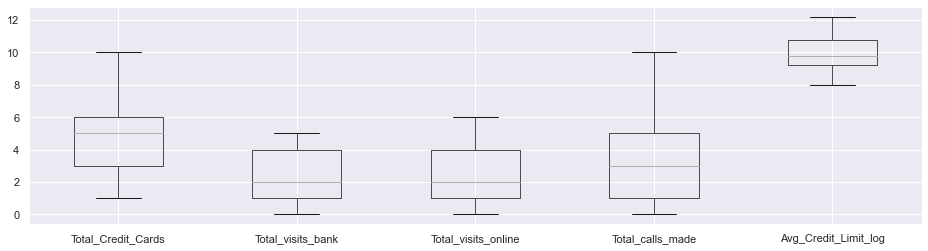

```python
df2.boxplot(figsize=(16,4))
```

`Outliers removed!`

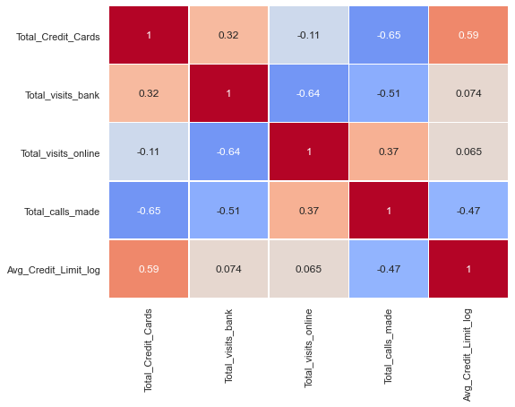

```python
# Correlations heat map

sns.set(rc={'figure.figsize':(8, 6)})
sns.heatmap(df2.corr(),
            annot=True,
            linewidths=0.5,
            center=0,
            cbar=False,
            cmap="coolwarm")
plt.show()
```

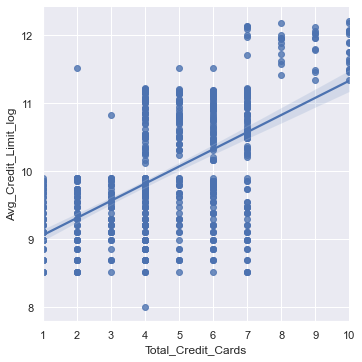

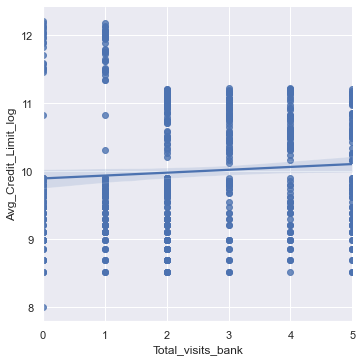

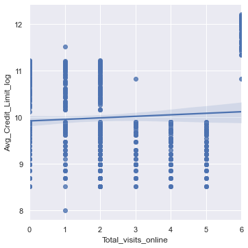

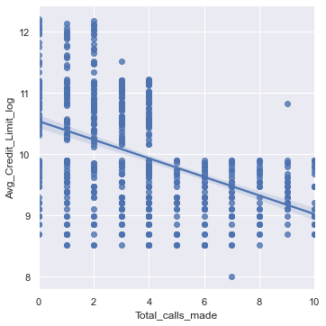

```python
#Plot high correlations with Avr Credit Limit

features=[col for col in df2.columns if col != 'Avg_Credit_Limit_log']

for i in features:

    sns.lmplot(y="Avg_Credit_Limit_log", x=i, data=df2);
    plt.show()
```

### K-means clustering, elbow plot and clusters analysis using boxplot

### Data Scaling

```python
df_z = df2.apply(zscore)
df_z.head()
```

|  | Total_Credit_Cards | Total_visits_bank | Total_visits_online | Total_calls_made | Avg_Credit_Limit_log |
| --- | --- | --- | --- | --- | --- |
| 0 | -1.249225 | -0.860451 | -0.662219 | -1.251537 | 1.630500 |
| 1 | -0.787585 | -1.473731 | 2.032383 | 1.891859 | 0.885383 |
| 2 | 1.058973 | -0.860451 | 0.415622 | 0.145528 | 0.885383 |
| 3 | 0.135694 | -0.860451 | -0.662219 | 0.145528 | 0.336263 |
| 4 | 0.597334 | -1.473731 | 2.032383 | -0.203739 | 1.630500 |

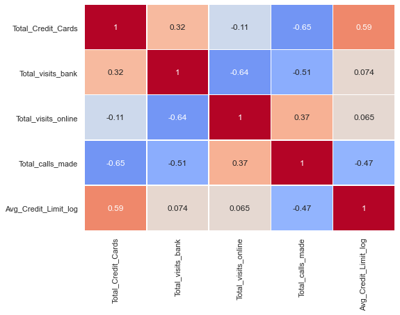

```python
# Correlations heat map

sns.set(rc={'figure.figsize':(8, 6)})
sns.heatmap(df_z.corr(),
            annot=True,
            linewidths=0.5,
            center=0,
            cbar=False,
            cmap="coolwarm")
plt.show()
```

### Elbow method

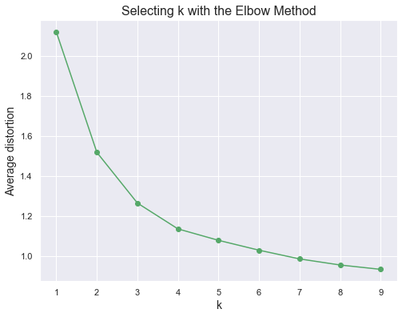

```python
#Finding optimal no. of clusters
from scipy.spatial.distance import cdist

clusters=range(1,10)
meanDistortions=[]

for k in clusters:
    model=KMeans(n_clusters=k)
    model.fit(df_z)
    prediction=model.predict(df_z)
    meanDistortions.append(sum(np.min(cdist(df_z, model.cluster_centers_, 'euclidean'), axis=1)) / df_z
                           .shape[0])


plt.plot(clusters, meanDistortions, 'go-')
plt.xlabel('k', fontsize=14)
plt.ylabel('Average distortion', fontsize=14)
plt.title('Selecting k with the Elbow Method', fontsize=16)
```

`Based on Elbow plot 6 clusters can be applied to have relatively small distance of 1 between the clusters centroids (based on Euclidean distanse).`

```python
#Set the value of k=6

kmeans = KMeans(n_clusters=6, n_init = 20, max_iter=500, random_state=99645)
```

```python
kmeans.fit(df_z)
```

```
KMeans(max_iter=500, n_clusters=6, n_init=20, random_state=99645)
```

```python
centroids = kmeans.cluster_centers_
centroids
```

```
array([[-1.04626252, -0.84458993,  0.58287295,  0.58813224, -0.76081185],
       [ 0.3630166 ,  0.02694716, -0.67038414, -0.51596149,  0.76458424],
       [-1.07397269, -0.96266399,  0.83478204,  1.74956516, -0.69436045],
       [ 1.86222621, -1.10576269,  2.03238261, -0.87432983,  1.96652652],
       [ 0.4109023 ,  1.28602988, -0.68294638, -0.56979653,  0.76770603],
       [ 0.35728108,  0.7994943 , -0.66581148, -0.57396086, -0.77231846]])
```

```python
## creating a new dataframe only for labels and converting it into categorical variable
df_labels = pd.DataFrame(kmeans.labels_ , columns = list(['labels']))

df_labels['labels'] = df_labels['labels'].astype('category')

# Joining the label dataframe with the original, non-scaled data frame.
df_labeled = df.join(df_labels)

df_labeled.head()
```

|  | Sl_No | Customer Key | Avg_Credit_Limit | Total_Credit_Cards | Total_visits_bank | Total_visits_online | Total_calls_made | labels |
| --- | --- | --- | --- | --- | --- | --- | --- | --- |
| 0 | 1 | 87073 | 100000 | 2 | 1 | 1 | 0 | 1 |
| 1 | 2 | 38414 | 50000 | 3 | 0 | 10 | 9 | 2 |
| 2 | 3 | 17341 | 50000 | 7 | 1 | 3 | 4 | 1 |
| 3 | 4 | 40496 | 30000 | 5 | 1 | 1 | 4 | 1 |
| 4 | 5 | 47437 | 100000 | 6 | 0 | 12 | 3 | 3 |

```python
df_labeled['labels'].value_counts(normalize=True)*100
```

```
5    22.727273
1    20.000000
0    17.575758
2    16.363636
4    15.757576
3     7.575758
Name: labels, dtype: float64
```

`Dropping variables of 'SI_No' and 'Customer Key' as non-relevant for the numerical analysis.`

```python
df_labeled_noID = df_labeled.drop(['Sl_No', 'Customer Key'], axis=1)

# Grouping by the created labels and sorting by the Avr Credit Limit

df_labeled_noID.groupby(['labels']).median().sort_values('Avg_Credit_Limit', ascending=False)
```

| labels | Avg_Credit_Limit | Total_Credit_Cards | Total_visits_bank | Total_visits_online | Total_calls_made |
| --- | --- | --- | --- | --- | --- |
| 3 | 145500.0 | 9.0 | 1.0 | 11.0 | 1.0 |
| 1 | 49000.0 | 6.0 | 2.0 | 1.0 | 2.0 |
| 4 | 44000.0 | 6.0 | 4.5 | 1.0 | 2.0 |
| 2 | 12000.0 | 2.0 | 1.0 | 4.0 | 9.0 |
| 0 | 11000.0 | 2.0 | 1.0 | 3.0 | 5.0 |
| 5 | 11000.0 | 6.0 | 4.0 | 1.0 | 2.0 |

`Since Avr Credit Limit has significantly larger values, separating it from the others into different data frame.`

```python
df_AvgCreditLimit_labeled = df_labeled_noID[['Avg_Credit_Limit', 'labels']]

df_AllOthers_labeled = df_labeled_noID.drop(['Avg_Credit_Limit'], axis=1)
```

### Boxplots

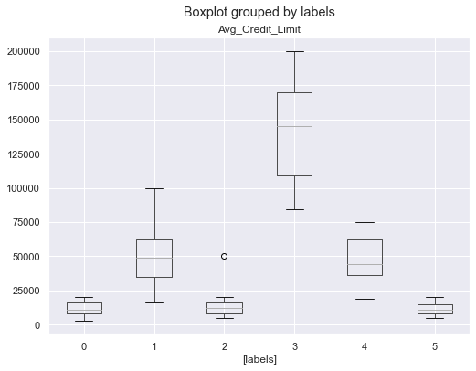

```python
df_AvgCreditLimit_labeled.boxplot(by = 'labels', figsize=(8, 6))
```

[output not shown]

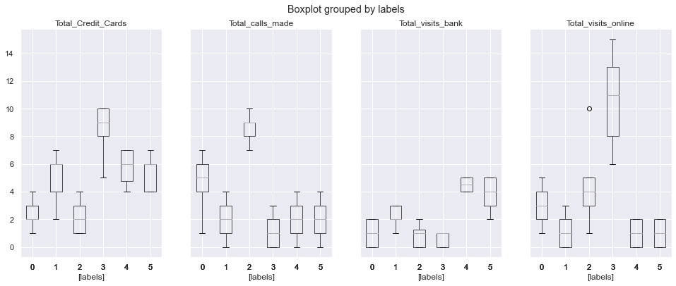

```python
df_AllOthers_labeled.boxplot(by = 'labels',  layout=(1,4), figsize=(16, 6))
```

### Insights:

- Group #3: highest Avr Credit Limit, Total Credit Cards and Total Visits Online; lowest number of Total Calls Made and total Visits Bank (can be people with high income or younger age, onliners); 7.5% only.
- Groups #1 and #4: have similar Avr Credit Limit, Total Credit Cards and Total Visits Online, although #4 have highest Total Visits bank, onsiters.
- Groups #0, #2 and #5: have similar low Avr Credit Limit, although different in communications means, when #5 have higher number of Credit Cards and low number of calls and online visits, they prefer Bank onsite visits (can be higher age population); #2 have highest number of calls.

### Hierarchical clustering (with different linkages), dendrogram and cophenetic coeff. Cluster analysis with boxplot

```python
from scipy.cluster.hierarchy import cophenet, dendrogram, linkage
from scipy.spatial.distance import pdist

from sklearn.cluster import AgglomerativeClustering
```

```python
# Average linkage
Z = linkage(df_z, metric='euclidean', method='average')
c, coph_dists = cophenet(Z , pdist(df_z))

c
```

```
0.8584888812215749
```

```python
# Complete linkage
Z = linkage(df_z, metric='euclidean', method='complete')
c, coph_dists = cophenet(Z , pdist(df_z))

c
```

```
0.8170723908144876
```

```python
# Single linkage
Z = linkage(df_z, metric='euclidean', method='single')
c, coph_dists = cophenet(Z , pdist(df_z))

c
```

```
0.5944416547336815
```

```python
# Ward linkage
Z = linkage(df_z, metric='euclidean', method='ward')
c, coph_dists = cophenet(Z , pdist(df_z))

c
```

```
0.7822411510149047
```

### Insights:

- Average linkage gives the highest cophenetic coefficient, single is the lowest.

```python
model = AgglomerativeClustering(n_clusters=6, affinity='euclidean',  linkage='average')
```

```python
model.fit(df_z)
```

```
AgglomerativeClustering(linkage='average', n_clusters=6)
```

```python
#Asigning labels to the original, non-scaled data frame
df_hc=df.copy()

df_hc['labels'] = model.labels_
df_hc.head()
```

|  | Sl_No | Customer Key | Avg_Credit_Limit | Total_Credit_Cards | Total_visits_bank | Total_visits_online | Total_calls_made | labels |
| --- | --- | --- | --- | --- | --- | --- | --- | --- |
| 0 | 1 | 87073 | 100000 | 2 | 1 | 1 | 0 | 0 |
| 1 | 2 | 38414 | 50000 | 3 | 0 | 10 | 9 | 4 |
| 2 | 3 | 17341 | 50000 | 7 | 1 | 3 | 4 | 5 |
| 3 | 4 | 40496 | 30000 | 5 | 1 | 1 | 4 | 1 |
| 4 | 5 | 47437 | 100000 | 6 | 0 | 12 | 3 | 2 |

```python
df_hc['labels'].value_counts(normalize=True)*100
```

```
1    58.030303
3    33.787879
2     7.575758
0     0.303030
5     0.151515
4     0.151515
Name: labels, dtype: float64
```

`This suggest 3 groups only. In order to perform comparision with KMeans, performing with 'ward' linkage with 6 clusters.`

```python
model = AgglomerativeClustering(n_clusters=6, affinity='euclidean',  linkage='ward')
model.fit(df_z)
```

```
AgglomerativeClustering(n_clusters=6)
```

```python
df_hc=df.copy()

df_hc['labels'] = model.labels_
df_hc.head()
```

|  | Sl_No | Customer Key | Avg_Credit_Limit | Total_Credit_Cards | Total_visits_bank | Total_visits_online | Total_calls_made | labels |
| --- | --- | --- | --- | --- | --- | --- | --- | --- |
| 0 | 1 | 87073 | 100000 | 2 | 1 | 1 | 0 | 4 |
| 1 | 2 | 38414 | 50000 | 3 | 0 | 10 | 9 | 2 |
| 2 | 3 | 17341 | 50000 | 7 | 1 | 3 | 4 | 4 |
| 3 | 4 | 40496 | 30000 | 5 | 1 | 1 | 4 | 4 |
| 4 | 5 | 47437 | 100000 | 6 | 0 | 12 | 3 | 5 |

```python
df_hc['labels'].value_counts(normalize=True)*100
```

```
0    26.818182
1    17.272727
2    16.818182
3    16.666667
4    14.848485
5     7.575758
Name: labels, dtype: float64
```

`This groups spread is similar to the KMeans output, so that using 'ward' in order to make comparision later.`

### Dendograms

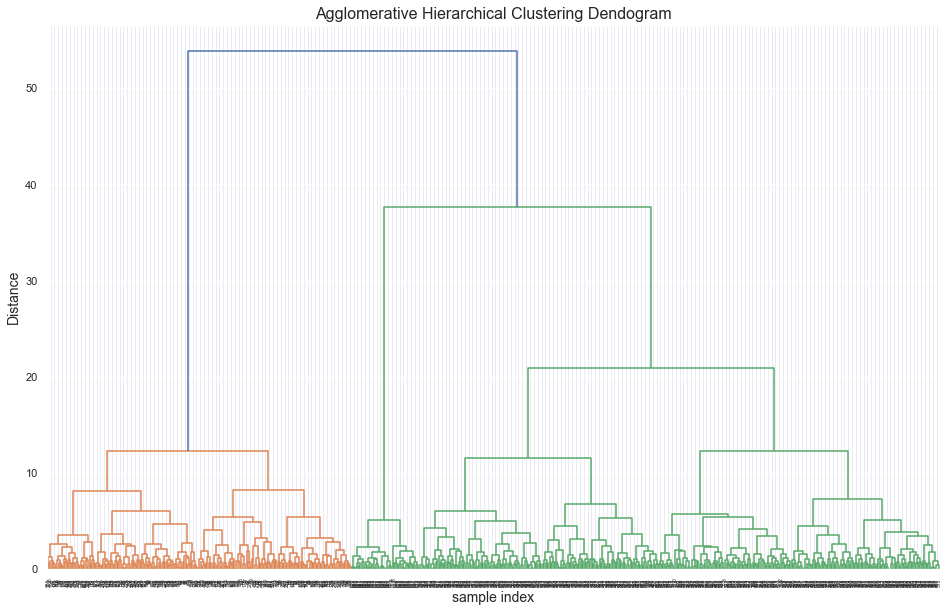

```python
plt.figure(figsize=(16, 10))
plt.title('Agglomerative Hierarchical Clustering Dendogram', fontsize=16)
plt.xlabel('sample index', fontsize=14)
plt.ylabel('Distance', fontsize=14)
dendrogram(Z, leaf_rotation=90)
plt.show()
```

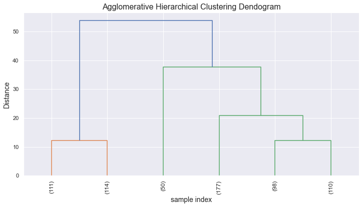

```python
# Truncated Dendogram

plt.figure(figsize=(12, 6))
plt.title('Agglomerative Hierarchical Clustering Dendogram', fontsize=16)
plt.xlabel('sample index', fontsize=14)
plt.ylabel('Distance', fontsize=14)
dendrogram(Z,
           truncate_mode='lastp',
           p=6,
           leaf_rotation=90)
plt.show()
```

```python
#Dropping IDs as non-relevant for the analysis, sorting by the Avr Credit Limit

df_labeled_noID_hc = df_hc.drop(['Sl_No', 'Customer Key'], axis=1)

df_labeled_noID_hc.groupby(['labels']).median().sort_values('Avg_Credit_Limit', ascending=False)
```

| labels | Avg_Credit_Limit | Total_Credit_Cards | Total_visits_bank | Total_visits_online | Total_calls_made |
| --- | --- | --- | --- | --- | --- |
| 5 | 145500.0 | 9.0 | 1.0 | 11.0 | 1.0 |
| 4 | 54000.0 | 6.0 | 2.0 | 1.0 | 2.5 |
| 3 | 48000.0 | 6.0 | 4.0 | 1.0 | 2.0 |
| 0 | 13000.0 | 6.0 | 4.0 | 1.0 | 2.0 |
| 2 | 13000.0 | 2.0 | 1.0 | 4.0 | 9.0 |
| 1 | 10000.0 | 2.0 | 1.0 | 4.0 | 5.0 |

```python
#Separating Avr Credit Limit from other variables

df_AvgCreditLimit_hc = df_labeled_noID_hc[['Avg_Credit_Limit', 'labels']]

df_AllOthers_hc = df_labeled_noID_hc.drop(['Avg_Credit_Limit'], axis=1)
```

### Boxplots

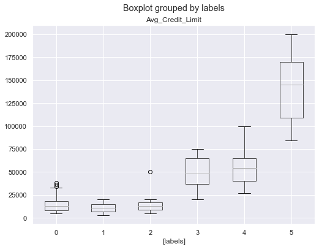

```python
df_AvgCreditLimit_hc.boxplot(by = 'labels', figsize=(8, 6))
```

[output not shown]

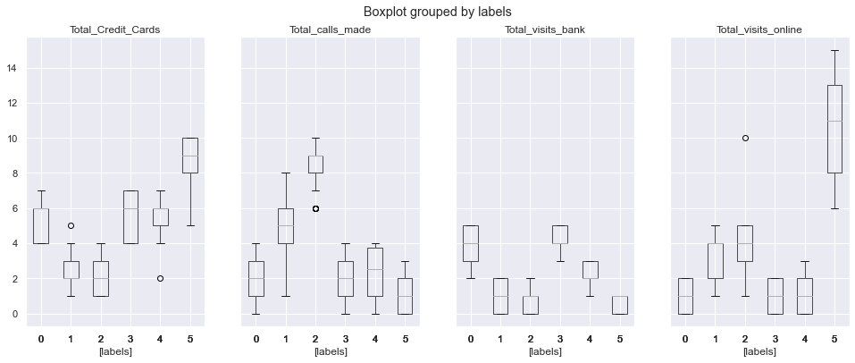

```python
df_AllOthers_hc.boxplot(by = 'labels',  layout=(1,4), figsize=(16, 6))
```

### Insights:

- Group #5: highest Avr Credit Limit, Total Credit Cards and Total Visits Online; lowest number of Total Calls Made and total Visits Bank (can be people with high income or younger age, onliners); 7.6% only.
- Groups #3 and #4: have similar Avr Credit Limit, Total Credit Cards and Total Visits Online, although #3 have highest Total Visits bank, onsiters.
- Groups #0, #1 and #2: have similar low Avr Credit Limit, although different in communications means, when #0 have higher number of Credit Cards among them and low number of calls and online visits, they prefer Bank onsite visits (can be higher age population); #2 have highest number of calls.

### Average Silhouettes score for both methods

```python
from scipy.cluster.hierarchy import fcluster
from sklearn.metrics import silhouette_score
```

```python
max_d = 6

Z = linkage(df_z, metric='euclidean', method='ward')

clusters = fcluster(Z, max_d, criterion='distance')
```

```python
# Avg Silhoutte Score for Hierarchical Clustering

silhouette_score(df_z, clusters)
```

```
0.21439983896385728
```

```python
# Avg Silhoutte Score for KMeans Clustering

clusters_km = kmeans.labels_

silhouette_score(df_z, clusters_km)
```

```
0.2513005759265579
```

### Comparison between KMeans and Hierarchical clustering

```python
print('From KMeans \n', df_labeled['labels'].value_counts())
print()
print('From Hierarchical clustering \n', df_hc['labels'].value_counts())
```

```
From KMeans
 5    150
1    132
0    116
2    108
4    104
3     50
Name: labels, dtype: int64

From Hierarchical clustering
 0    177
1    114
2    111
3    110
4     98
5     50
Name: labels, dtype: int64
```

`Very similar number of customers in each group.`

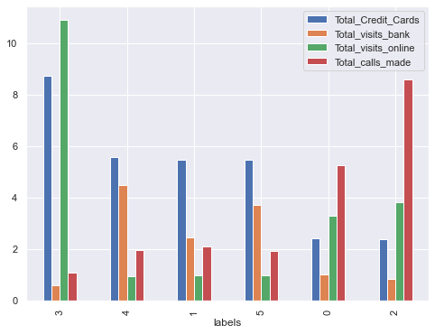

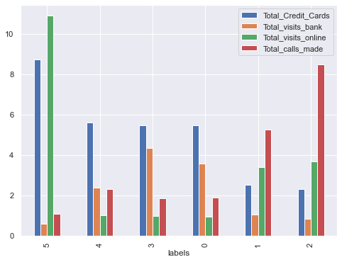

```python
#Bar plots on mean values for all variables exept Total Credit Limit, sorted by Total Credit cards,
#for both methods

df_AllOthers_labeled.groupby('labels').mean().sort_values('Total_Credit_Cards', ascending=False).plot(kind='bar')
plt.show()
df_AllOthers_hc.groupby('labels').mean().sort_values('Total_Credit_Cards', ascending=False).plot(kind='bar')
```

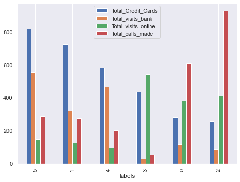

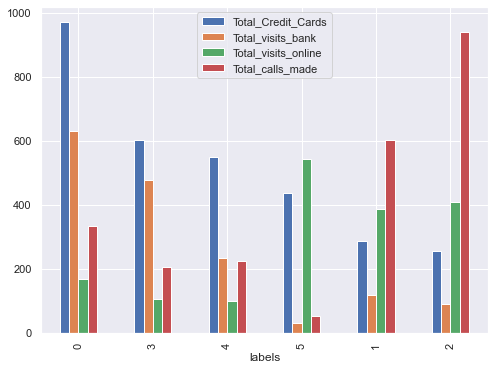

```python
#Bar plots on sum values for all variables exept Total Credit Limit, sorted by Total Credit cards,
#for both methods

df_AllOthers_labeled.groupby('labels').sum().sort_values('Total_Credit_Cards', ascending=False).plot(kind='bar')
plt.show()
df_AllOthers_hc.groupby('labels').sum().sort_values('Total_Credit_Cards', ascending=False).plot(kind='bar')
```

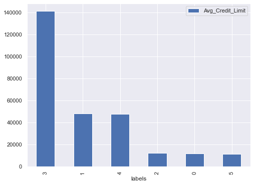

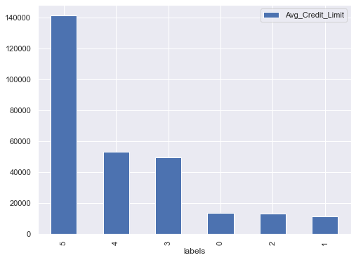

```python
#Bar plots on mean values for Avg Credit Limit variable, sorted,
#for both methods

df_AvgCreditLimit_labeled.groupby('labels').mean().sort_values('Avg_Credit_Limit', ascending=False).plot(kind='bar')
plt.show()
df_AvgCreditLimit_hc.groupby('labels').mean().sort_values('Avg_Credit_Limit', ascending=False).plot(kind='bar')
```

```python
df_labeled_noID.groupby(['labels']).median().sort_values('Avg_Credit_Limit', ascending=False)
```

| labels | Avg_Credit_Limit | Total_Credit_Cards | Total_visits_bank | Total_visits_online | Total_calls_made |
| --- | --- | --- | --- | --- | --- |
| 3 | 145500.0 | 9.0 | 1.0 | 11.0 | 1.0 |
| 1 | 49000.0 | 6.0 | 2.0 | 1.0 | 2.0 |
| 4 | 44000.0 | 6.0 | 4.5 | 1.0 | 2.0 |
| 2 | 12000.0 | 2.0 | 1.0 | 4.0 | 9.0 |
| 0 | 11000.0 | 2.0 | 1.0 | 3.0 | 5.0 |
| 5 | 11000.0 | 6.0 | 4.0 | 1.0 | 2.0 |

```python
df_labeled_noID_hc.groupby(['labels']).median().sort_values('Avg_Credit_Limit', ascending=False)
```

| labels | Avg_Credit_Limit | Total_Credit_Cards | Total_visits_bank | Total_visits_online | Total_calls_made |
| --- | --- | --- | --- | --- | --- |
| 5 | 145500.0 | 9.0 | 1.0 | 11.0 | 1.0 |
| 4 | 54000.0 | 6.0 | 2.0 | 1.0 | 2.5 |
| 3 | 48000.0 | 6.0 | 4.0 | 1.0 | 2.0 |
| 0 | 13000.0 | 6.0 | 4.0 | 1.0 | 2.0 |
| 2 | 13000.0 | 2.0 | 1.0 | 4.0 | 9.0 |
| 1 | 10000.0 | 2.0 | 1.0 | 4.0 | 5.0 |

### Analysis the clusters formed

```python
df_analysis_km = df_labeled.groupby(['labels'], axis=0).head(700)

df_analysis_km.head()
```

|  | Sl_No | Customer Key | Avg_Credit_Limit | Total_Credit_Cards | Total_visits_bank | Total_visits_online | Total_calls_made | labels |
| --- | --- | --- | --- | --- | --- | --- | --- | --- |
| 0 | 1 | 87073 | 100000 | 2 | 1 | 1 | 0 | 1 |
| 1 | 2 | 38414 | 50000 | 3 | 0 | 10 | 9 | 2 |
| 2 | 3 | 17341 | 50000 | 7 | 1 | 3 | 4 | 1 |
| 3 | 4 | 40496 | 30000 | 5 | 1 | 1 | 4 | 1 |
| 4 | 5 | 47437 | 100000 | 6 | 0 | 12 | 3 | 3 |

```python
df_analysis_km.shape
```

```
(660, 8)
```

```python
df_analysis_km.info()
```

```
<class 'pandas.core.frame.DataFrame'>
Int64Index: 660 entries, 0 to 659
Data columns (total 8 columns):
 #   Column               Non-Null Count  Dtype
---  ------               --------------  -----
 0   Sl_No                660 non-null    int64
 1   Customer Key         660 non-null    int64
 2   Avg_Credit_Limit     660 non-null    int64
 3   Total_Credit_Cards   660 non-null    int64
 4   Total_visits_bank    660 non-null    int64
 5   Total_visits_online  660 non-null    int64
 6   Total_calls_made     660 non-null    int64
 7   labels               660 non-null    category
dtypes: category(1), int64(7)
memory usage: 42.1 KB
```

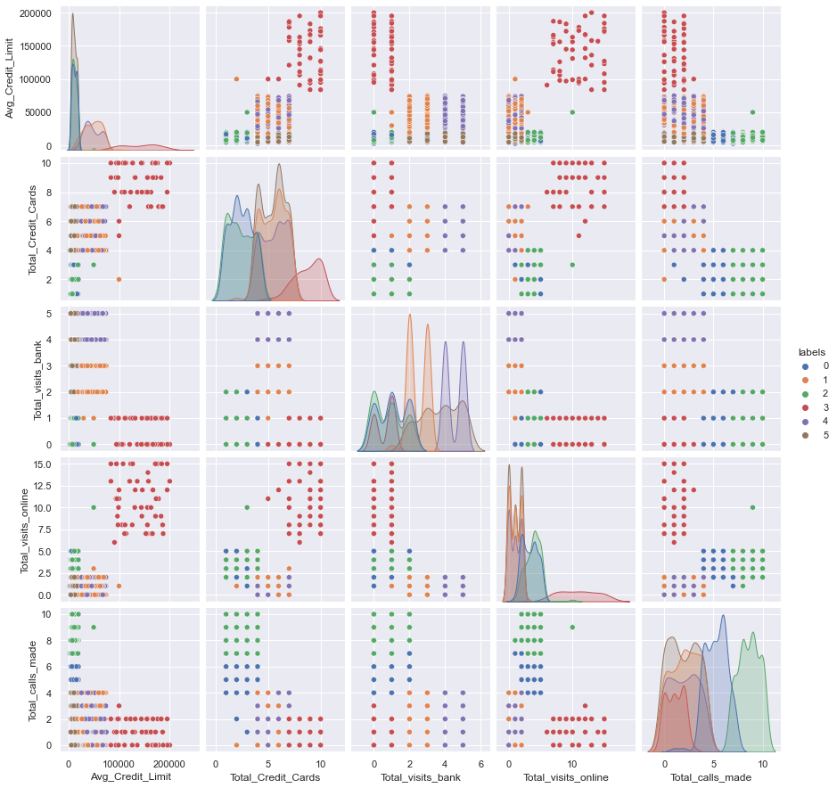

```python
df_analysis_km_noIDs = df_analysis_km.drop(['Sl_No', 'Customer Key'], axis=1)

sns.pairplot(df_analysis_km_noIDs, hue='labels')
```

### Conclusions:

1. How many different segments of customers: 6 different segment were found.
2. Main differences between these segments and recommendatiions:
   - Avg Credit Limit and Total number of credit cards is higher for the first three groups ('happy' customers), with different communication means: 'onliners' with the highest Credit Limit and credit cards; and two groups with 6 credit cards and about 45,000 credit limit, where one group made highest number of bank visits ('onsiters').
     - Recommendation to the bank: incraese online advertisement for the first group and incraese onsite advertisement for the latest group (among these three).
   - Avg Credit Limit and Total number of credit cards is low for the last three groups ('unhappy' customers), also with different communication means. **These groups need more customer support and marketing attention in general**.
   - Two groups with realtively high number of calls made and online visitors, about 2 credit cards on average.
     - Recommendation to the bank: phone marketing maybe helpful.
   - Group with 6 credit cards and very low communicators - they prefer making bank visits:
     - Recommendation to the bank: onsite marketing and increased onsite attention maybe helpful.